# Miniproject - data exploration

[Global Terrorism Database](https://www.kaggle.com/START-UMD/gtd)

# Instructions:

1. Download data set, Global Terrorism Database, from https://www.kaggle.com/START-UMD/gtd
2. Take a quick look at the data set. Check what's inside, how the data is structured, and where the data is corrupted (missing values, bad structure, etc).
3. Think and create 5 questions to the data. Try to ask yourself what's really interesting in the data set. What's not so obvious. E.g. some trends, patterns, correlations.
4. Create a jupyter notebook and use python, numpy, pandas, matplotlib (at least) to provide all the answers to your questions.
5. Create a new github repository, and put your jupyter notebook there.
6. Create readme.md file as well in your github root directory with all necessary instructions (what is in the repo, what libs are necessary to run the code, where to find data set and where to save it - this is necessary because the dataset is too big for github repo).
7. Provide the necessary documentation and introduction in your notebook using markdown language, at least: data source description, data structure, importing process, data processing process.
8. Put some data visualization in your notebook. Sometimes it's much easier to present the answer using a chart rather than numbers
9. Check if your notebook run smoothly - use 'Reset & Run All' command from the menu. Save it.
10. Export the notebook as HTML as well, and save the file in the repo.
11. Do not forget to commit/push all the changes to your repo on hithub.
12. Smile :) You did a good job!

FAQ:

1. Can I take a look at different solution provided at kaggle? Yes, you can. But check more than one solution. Try to understand what the authors are trying to solve, and how could it be used in your project. Try to find really good examples - easy to understand and not so complicated. Remember - you create the notebook as an instruction to someone else! Try to not complicate the process.
2. Can I take a look at my friend's solution, that he/she has just put on github? Yes, you can. But it's the smart way of solving the project. I'm sure that you want to be smarter in the next semester - so try to create a better solution and your own one :)
3. Jupyter notebook provide R kernel, so can I use R instead? Nope, R sucks. Even if you love R, try to solve the project using Python.

## Questions

1. What was the most popular attack types?
2. What was the most affected country by terrorism?
3. How many attacks had happened each year?
4. Which regions were the most affected ones?
5. Were the wounded more frequent than killed in terrorism attacks?

## Importing data

Data needed special encoding to be read properly.

```python
import csv
import numpy as np
import pandas as pd
from pprint import pprint
import matplotlib.pyplot as plt
%matplotlib inline

df = pd.read_csv('globalterrorismdb_0718dist.csv', encoding='ISO-8859-1')
df['date'] = pd.to_datetime(df['iyear'], format='%Y')
```

## Data source description

Data source contains 181691 records about terrorism attacks between 1970 and 2017.

```python
df_filtered = df[['iyear','imonth','iday','country_txt','region_txt']]
df_filtered.head(5)
```

|  | iyear | imonth | iday | country_txt | region_txt |
| --- | --- | --- | --- | --- | --- |
| 0 | 1970 | 7 | 2 | Dominican Republic | Central America & Caribbean |
| 1 | 1970 | 0 | 0 | Mexico | North America |
| 2 | 1970 | 1 | 0 | Philippines | Southeast Asia |
| 3 | 1970 | 1 | 0 | Greece | Western Europe |
| 4 | 1970 | 1 | 0 | Japan | East Asia |

## What was the most popular attack types?

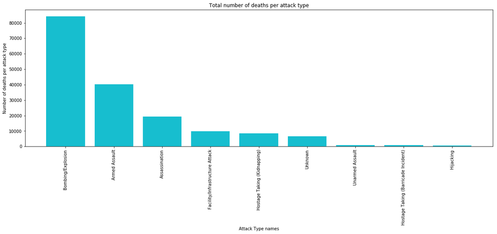

```python
dane1 =df[['attacktype1_txt','nkill']]
DANE_1 = dane1.groupby(['attacktype1_txt']).count().sort_values(by =['nkill', 'attacktype1_txt'], ascending=False).reset_index()
plt.figure(figsize=(20,6))
x = DANE_1['attacktype1_txt']
plt.xticks(rotation='vertical')
y = DANE_1['nkill']
plt.ylabel('Number of deaths per attack type')
plt.xlabel('Attack Type names')
plt.title('Total number of deaths per attack type')
plt.bar(x,y, color='C9')
plt.show()
```

## What was the most affected country by terrorism?

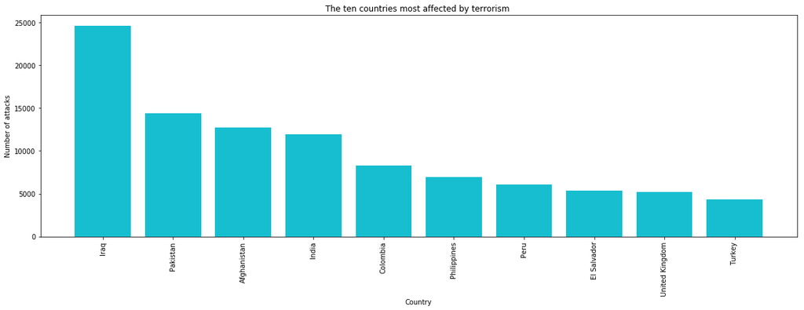

```python
dane2_1 = df[['eventid', 'country_txt']]
dane2 = df['eventid']
DANE_1 = dane2_1.groupby(['country_txt']).count().sort_values(by =['eventid', 'country_txt'], ascending=False).reset_index()
plt.figure(figsize=(20,6))
x = DANE_1['country_txt'][:10]
plt.xticks(rotation='vertical')
y = DANE_1['eventid'][:10]
plt.xlabel('Country')
plt.ylabel('Number of attacks')
plt.title('The ten countries most affected by terrorism ')
plt.bar(x,y, color= 'C9')
plt.show()
```

## How many attacks had happened each year?

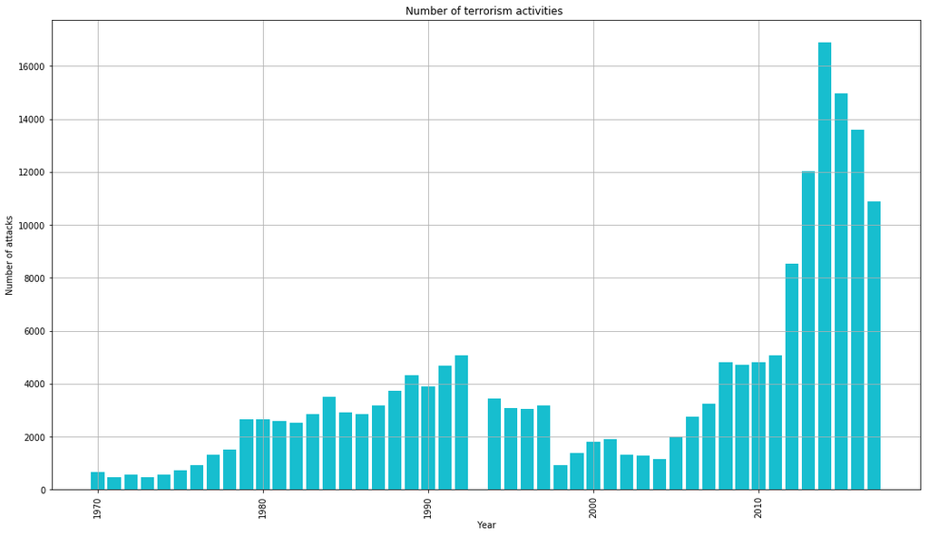

```python
dane3_1 = df[['iyear','eventid']]
DANE_3 = dane3_1.groupby(['iyear']).count().sort_values(by =['iyear', 'eventid'], ascending=False).reset_index()
plt.figure(figsize=(18,10))
x = DANE_3['iyear']
plt.xticks(rotation='vertical')
y = DANE_3['eventid']
plt.xlabel('Year')
plt.ylabel('Number of attacks')
plt.title('Number of terrorism activities ')
plt.grid()
plt.bar(x,y, color= 'C9')
plt.show()
```

## Which regions were the most affected ones?

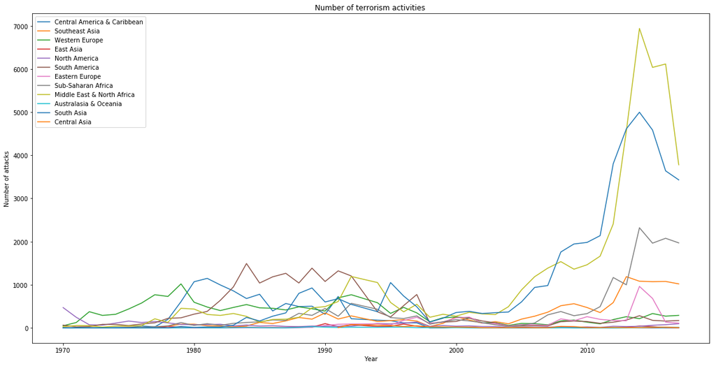

```python
df1 = df[df['imonth'] != 0]
DANE_4 = df1[['eventid', 'date', 'region_txt']]
regions = DANE_4['region_txt'].unique()
plt.figure(figsize=(20, 10))

for region in regions:
    dane = DANE_4[DANE_4['region_txt'] == region].groupby('date').count().reset_index()
    x = dane['date']
    y = dane['eventid']
    plt.plot(x, y, label=region)

plt.xlabel('Year')
plt.ylabel('Number of attacks')
plt.title('Number of terrorism activities ')
plt.legend()
plt.show()
```

## Were the wounded more frequent than killed in terrorism attacks?

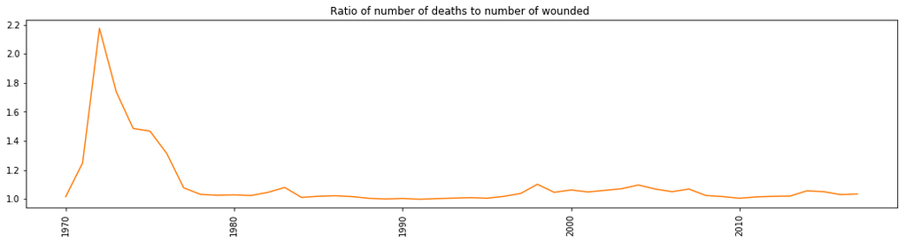

```python
dane5_1 = df[['iyear', 'nkill', 'nwound','eventid']]
DANE_5 = dane5_1.groupby(['iyear']).count().sort_values(by =['iyear', 'nkill'], ascending=False).reset_index()
plt.figure(figsize=(18, 4))
x = DANE_5['iyear']
plt.xticks(rotation='vertical')
y = DANE_5['nkill']
y1 = DANE_5['nwound']
z = y / y1
plt.plot(x, z, color='C1')
plt.title('Ratio of number of deaths to number of wounded ')
plt.show()
```